# PROJECT 1

INTRODUCTION

The Electric Vehicle Population Data, available on data.gov,(https://catalog.data.gov/dataset/electric-vehicle-population-size-history-by-county), offers insights into the registration of Battery Electric Vehicles (BEVs) and Plug-in Hybrid Electric Vehicles (PHEVs) through the Washington State Department of Licensing (DOL). This dataset tracks the monthly registration counts by county for both passenger vehicles and trucks. It is a valuable resource for researchers, analysts, and policymakers interested in understanding electric vehicle adoption trends within Washington State. The information provided is derived from the integration of data from the National Highway Traffic Safety Administration (NHTSA), the Environmental Protection Agency (EPA), and the DOL's titling and registration records.

```python
import warnings
warnings.simplefilter(action='ignore', category=FutureWarning)
warnings.simplefilter(action='ignore', category=DeprecationWarning)
import numpy as np
import pandas as pd
import matplotlib.pyplot as plt
import seaborn as sns
```

```python
projectdata =('Electric_Vehicle_Population_Size_History_By_County.csv')
df = pd.read_csv(projectdata)
df.head()
print(df.head)
```

```
<bound method NDFrame.head of                     Date          County State Vehicle Primary Use  \
0      September 30 2022       Riverside    CA           Passenger
1       December 31 2022  Prince William    VA           Passenger
2        January 31 2020          Dakota    MN           Passenger
3           June 30 2022           Ferry    WA               Truck
4           July 31 2021         Douglas    CO           Passenger
...                  ...             ...   ...                 ...
20814    January 31 2023      Rockingham    NH           Passenger
20815       July 31 2020     Carson City    NV           Passenger
20816   February 28 2022          Island    WA           Passenger
20817   December 31 2020       San Diego    CA           Passenger
20818   November 30 2019       Goochland    VA           Passenger

       Battery Electric Vehicles (BEVs)  \
0                                     7
```

[output cut: 38 more lines]

PREPROCESSING

```python
df['Date'] = pd.to_datetime(df['Date'])

df.drop(['Date', 'County', 'State'], axis=1, inplace=True)
missing_values=df.isnull().sum()
datanotmissing=missing_values.dropna()



# Select the quantitative columns
quantColumns = df.select_dtypes(include=['int64', 'float64'])

# Get the statistical summary
quantColanalysis = quantColumns.describe()

# Print the statistical summary
print(quantColanalysis)
```

```
       Battery Electric Vehicles (BEVs)  \
count                      20819.000000
mean                         217.516211
std                         2278.533317
min                            0.000000
25%                            0.000000
50%                            1.000000
75%                            3.000000
max                        72333.000000

       Plug-In Hybrid Electric Vehicles (PHEVs)  Electric Vehicle (EV) Total  \
count                              20819.000000                 20819.000000
mean                                  80.063644                   297.579855
std                                  646.373208                  2915.504792
min                                    0.000000                     0.000000
25%                                    0.000000                     1.000000
50%                                    1.000000                     1.000000
75%                                    2.000000                     4.000000
max                                17501.000000                 89834.000000

       Non-Electric Vehicle Total  Total Vehicles  Percent Electric Vehicles
count                2.081900e+04    2.081900e+04               20819.000000
mean                 2.509806e+04    2.539564e+04                   4.139216
std                  1.067324e+05    1.090860e+05                  11.055350
min                  0.000000e+00    1.000000e+00                   0.000000
25%                  4.300000e+01    4.400000e+01                   0.390000
50%                  1.630000e+02    1.650000e+02                   1.220000
75%                  8.380000e+03    8.421500e+03                   2.995000
max                  1.399823e+06    1.430937e+06                 100.000000
```

SUMMARY DATA ANALYSIS

```
       Battery Electric Vehicles (BEVs)  \
count                      20819.000000
mean                         217.516211
std                         2278.533317
min                            0.000000
25%                            0.000000
50%                            1.000000
75%                            3.000000
max                        72333.000000

       Plug-In Hybrid Electric Vehicles (PHEVs)  Electric Vehicle (EV) Total  \
count                              20819.000000                 20819.000000
mean                                  80.063644                   297.579855
std                                  646.373208                  2915.504792
min                                    0.000000                     0.000000
25%                                    0.000000                     1.000000
50%                                    1.000000                     1.000000
75%                                    2.000000                     4.000000
max                                17501.000000                 89834.000000

       Non-Electric Vehicle Total  Total Vehicles  Percent Electric Vehicles
count                2.081900e+04    2.081900e+04               20819.000000
mean                 2.509806e+04    2.539564e+04                   4.139216
std                  1.067324e+05    1.090860e+05                  11.055350
min                  0.000000e+00    1.000000e+00                   0.000000
25%                  4.300000e+01    4.400000e+01                   0.390000
50%                  1.630000e+02    1.650000e+02                   1.220000
75%                  8.380000e+03    8.421500e+03                   2.995000
max                  1.399823e+06    1.430937e+06                 100.000000
```

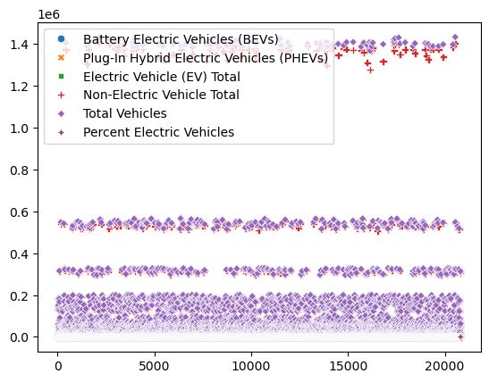

```python
# Numerical summary
numerical_summary = df.describe()
print(numerical_summary)

# Graphical summary
sns.scatterplot(df)
plt.show()
```

```
                                          Battery Electric Vehicles (BEVs)  \
Battery Electric Vehicles (BEVs)                                  1.000000
Plug-In Hybrid Electric Vehicles (PHEVs)                          0.981358
Electric Vehicle (EV) Total                                       0.999092
Non-Electric Vehicle Total                                        0.779821
Total Vehicles                                                    0.789699
Percent Electric Vehicles                                        -0.012019

                                          Plug-In Hybrid Electric Vehicles (PHEVs)  \
Battery Electric Vehicles (BEVs)                                          0.981358
Plug-In Hybrid Electric Vehicles (PHEVs)                                  1.000000
Electric Vehicle (EV) Total                                               0.988656
Non-Electric Vehicle Total                                                0.870713
Total Vehicles                                                            0.878351
Percent Electric Vehicles                                                -0.020843

                                          Electric Vehicle (EV) Total  \
Battery Electric Vehicles (BEVs)                             0.999092
Plug-In Hybrid Electric Vehicles (PHEVs)                     0.988656
Electric Vehicle (EV) Total                                  1.000000
Non-Electric Vehicle Total                                   0.802487
Total Vehicles                                               0.811900
Percent Electric Vehicles                                   -0.014014

                                          Non-Electric Vehicle Total  \
Battery Electric Vehicles (BEVs)                            0.779821
Plug-In Hybrid Electric Vehicles (PHEVs)                    0.870713
Electric Vehicle (EV) Total                                 0.802487
Non-Electric Vehicle Total                                  1.000000
Total Vehicles                                              0.999873
Percent Electric Vehicles                                  -0.063489

                                          Total Vehicles  \
Battery Electric Vehicles (BEVs)                0.789699
Plug-In Hybrid Electric Vehicles (PHEVs)        0.878351
Electric Vehicle (EV) Total                     0.811900
Non-Electric Vehicle Total                      0.999873
Total Vehicles                                  1.000000
Percent Electric Vehicles                      -0.062494

                                          Percent Electric Vehicles
Battery Electric Vehicles (BEVs)                          -0.012019
Plug-In Hybrid Electric Vehicles (PHEVs)                  -0.020843
Electric Vehicle (EV) Total                               -0.014014
Non-Electric Vehicle Total                                -0.063489
Total Vehicles                                            -0.062494
Percent Electric Vehicles                                  1.000000
```

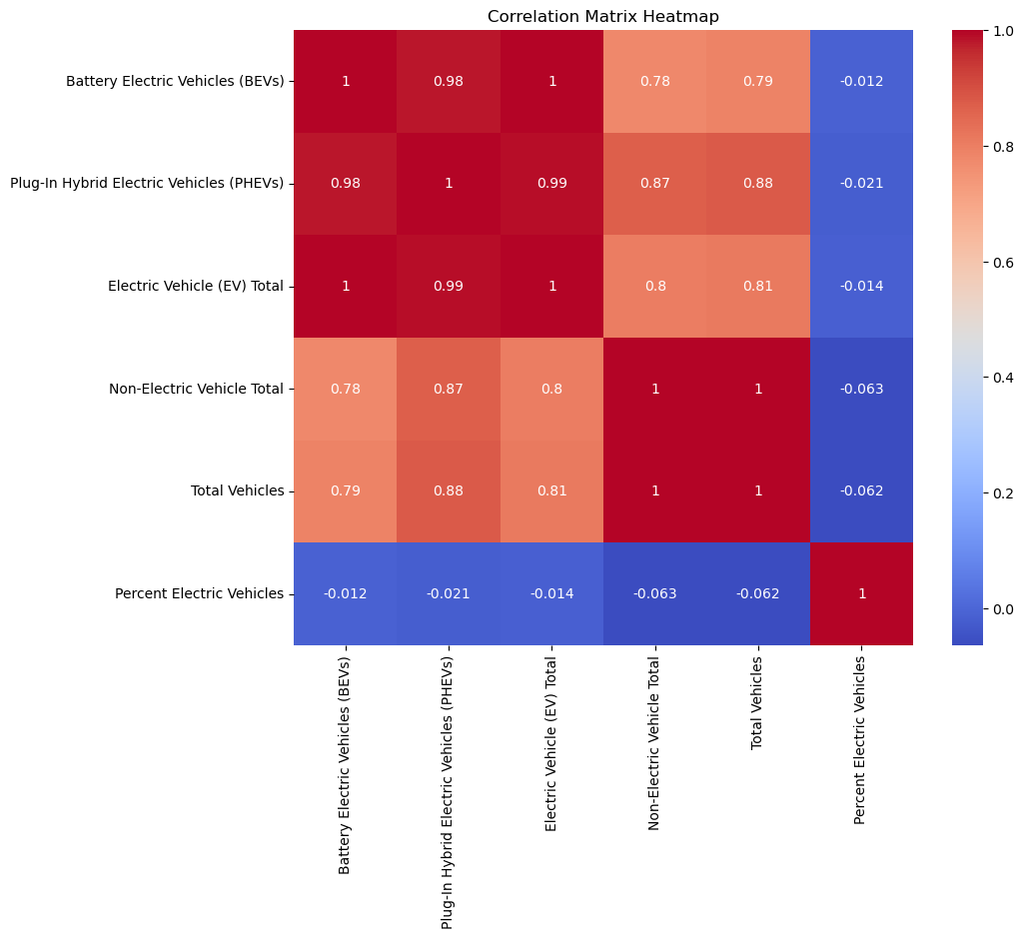

```python
# Create correlation matrix
corr_matrix = quantColumns.corr()

# Print the correlation matrix
print(corr_matrix)
plt.figure(figsize=(10, 8))
sns.heatmap(corr_matrix, annot=True, cmap='coolwarm')
plt.title('Correlation Matrix Heatmap')
plt.show()
```

```python
# Select three pairs of columns
pairs = [('Battery Electric Vehicles (BEVs)', 'Plug-In Hybrid Electric Vehicles (PHEVs)'),
         ('Plug-In Hybrid Electric Vehicles (PHEVs)', 'Non-Electric Vehicle Total'),
         ('Battery Electric Vehicles (BEVs)', 'Non-Electric Vehicle Total')]

# Calculate and print the correlation for each pair
for pair in pairs:
    corr = df[pair[0]].corr(df[pair[1]])
    print(f'Correlation between {pair[0]} and {pair[1]}: {corr}')
```

```
Correlation between Battery Electric Vehicles (BEVs) and Plug-In Hybrid Electric Vehicles (PHEVs): 0.9813584261124682
Correlation between Plug-In Hybrid Electric Vehicles (PHEVs) and Non-Electric Vehicle Total: 0.8707133558457827
Correlation between Battery Electric Vehicles (BEVs) and Non-Electric Vehicle Total: 0.7798212378906964
```

DISCUSSION

QUESTION 1 - Can the number of charging stations, average income, population density, and environmental policies in a county predict the adoption rate of electric vehicles (categorized as high, medium, or low)?

QUESTION 2 - Do factors such as average commute distance, public transportation availability, electric vehicle incentives, and average electricity cost in a county predict the percentage increase in electric vehicle registrations year over year?